# chilluminativity_notebook

I’ll be loosely following the tutorial linked below. (https://www.tidytextmining.com/tidytext.html#tidyausten) Hopefully this helps me learn, because it sure ain’t gonna be useful elsewhere…

# plz use install.packages() to install packages if an error pops up saying you don’t have it in your library

```r
library(tidyverse)
library(ggplot2)
library(dplyr)
library(stringr)
library(tidytext)
```

Before analysis, we have to change the format into tidy text to follow the tutorial.

Load in raw data sourced from Harry’s tweeter (https://docs.google.com/document/d/13R9hPoEFmLJI8H9kPYt291hjHokIBFQ5ci9uaOmO4dY/edit) And then change the format. Extra info based on the original text like the row number can also be included in this step.

```r
script <- read_lines("./raw/Chilluminativity - Script Public.txt") #load in plaintext
script <- tibble(script) #change it to tibble format
script <- script %>% mutate(line_number = row_number()) #add row number
script <- unnest_tokens(script, word, script) #change to tidy format
```

Script is a table of all the words in the script and the line that they are on

We can count all the words easily and visualize it in a graph.

```r
count(script, word, sort = TRUE) #count the words
```

| word | n |
| --- | --- |
| the | 100 |
| to | 75 |
| and | 60 |
| a | 53 |
| mary | 43 |
| you | 42 |
| wise | 39 |
| my | 37 |
| i | 36 |
| joseph | 35 |

[output cut: 704 more lines]

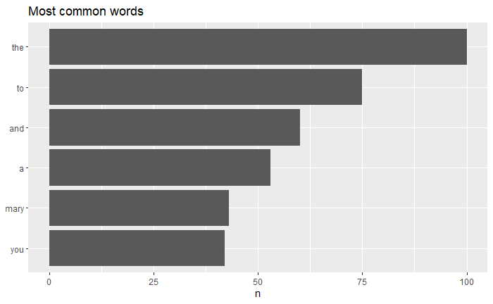

```r
script %>%
  count(word, sort = TRUE) %>%
  filter(n > 40) %>% # only graph most common words
  mutate(word = reorder(word, n)) %>% #reorder so the most frequent words are at the top
  ggplot(aes(word, n)) + #graph the counted words
  geom_col() +
  xlab(NULL) +
  ggtitle("Most common words") +
  coord_flip()
```

As you can see from our analysis, the most common word is “the” followed by “to”, “and” and “a”. Pretty boring results tbh.

Save this graph

```r
ggsave("./output/common_words.jpg")
```

Let’s try some sentiment analysis now. Sentiment analysis is kinda supposed to tell us what E M O T I O N S are in the text, in case you are incapable of feeling them yourself *insert david molyneux joke here*.

The bing dataset will tell you if a word has positive or negative vibes according to SCIENCE!

(citation for bing dataset is: Minqing Hu and Bing Liu. “Mining and Summarizing Customer Reviews.” Proceedings of the ACM SIGKDD International Conference on Knowledge Discovery and Data Mining (KDD-2004), Aug 22-25, 2004, Seattle, Washington, USA.

See: http://www.cs.uic.edu/~liub/FBS/sentiment-analysis.html#lexicon).

```r
bing <- get_sentiments("bing") #use the bing dataset
sentiment_of_script <- script %>%
  inner_join(bing) #join the bing data to the script
sentiment_of_script <- sentiment_of_script %>%
  mutate(vibes = recode(sentiment, #vibes is whether a word is positive or negative in number format
                        "positive" = "1", #make sentiment a numeric value
                        "negative" = "-1")) #where 1 = positive, -1 = negative
sentiment_of_script$vibes <- as.numeric(sentiment_of_script$vibes) #convert from chr to dbl
sentiment_of_script_by_line <- sentiment_of_script %>%
  group_by(line_number) %>%
  summarize(vibes = mean(as.numeric(vibes))) #make a line by line summary of the vibes
sentiment_of_script_by_line$cum_vibes <- cumsum(sentiment_of_script_by_line$vibes)#cumulative vibes by line
```

We can now graph the vibes throughout each line of the script

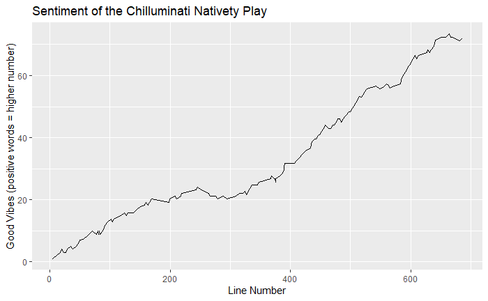

```r
ggplot(data = sentiment_of_script_by_line, aes(x = line_number, y = cum_vibes, group = 1)) + #make basic graph
  geom_line() + #show data as line
  ggtitle("Sentiment of the Chilluminati Nativety Play") + #add title
  xlab("Line Number") + #title of x axis
  ylab("Good Vibes (positive words = higher number)") #title of y axis
```

That’s nice, it looks like a very positive play, with a minor dip in mood a bit before line 300.

So what is this dip?

```r
script %>%
  filter(line_number %in% (270:300))
```

| line_number | word |
| --- | --- |
| 270 | peasant |
| 270 | 2 |
| 270 | oh |
| 270 | well |
| 270 | that |
| 270 | sucks |
| 270 | bye |
| 273 | scrooge |
| 273 | actually |
| 273 | now |

[output cut: 119 more lines]

Sounds like the end of scene 3 is a sad time :(

Save the graph we just made.

```r
ggsave("./output/vibes_by_line.jpg")
```

Thanks and byeee~